# Exploring the BRFSS data

## Setup

### Load packages

```r
library(ggplot2)
library(dplyr)
```

### Load data

Make sure your data and R Markdown files are in the same directory. When loaded your data file will be called `brfss2013`. Delete this note when before you submit your work.

```r
load("brfss2013.RData")
```

## Part 1: Data

According to the website, the data was collected by random sampling.There are 491775 observations of which 58548 completed the survey partially, which is only about 12%. Only 5, of them have `NA` as `dispcode`, which is were survey had very less fields properly responded. The rest almost 87% completed the survey fully.

The data has been collected by telephone surveys or online forms. This was randomly sampled. So they can be generalized to the US population.

Though there could be some people without internet or telephone.

## Part 2: Research questions

**Research quesion 1:**

In this section we are interested in finding out the relation between racial demography and high school dropouts or didn’t attend high school.What we want to find out precisely is that does race really matter in case of high school dropouts or not attending high school? This research can be useful if a govt. needs to implement affirmative action and check the progress of the minorities. For this we will calculate the conditional probability of not completing high school given the person’s race.

**Research quesion 2:**

In this part we are interested in finding out if eating fruits and vegetables does keep general health good or not. What we are basically asking is that, is there any relation between fruit and vegetable consumption with general health? For this we will try to find out whether the variables are connected or not and if connected, how are they connected ?  
People generally forget how important fruits and vegetables are important for our health. Here we try to address if everyone should try them to include in our diets.

**Research quesion 3:** In this part we are interested in finding out if there is any relation between racial demography, given by, `X_racegr3` and bodymass index, given by `X_bmi5cat`. Particularly we are interested in proportions of overweights or obese people across racial demography.  
Our main question here, Is there any dependence of “Overweights or Obese” on races ? This question’s answer might address the general eating habits over the population. This can also address how health strategies should be addressed across communities. This data can also open up avenues for more research as to find out why some specific communities tend to get more overweight ? There might be some genetic component or some specific life habit that causes this.

## Part 3: Exploratory data analysis

**Research quesion 1:**

For this research question we will look at two variables, `X_educag`, in which we are most interested in the frequency shown by `Did not graduate high school`, and the variable `X_racegr3`, which gives us the information about the racial demography of the respondents.

Let us first check the distribution of the racial demography. We will include the data by ignoring the `NA` values. That is to say, the people who responded to both education level questions and the racial category questions. The number of non respondents of these questions are low in number compared to the total frequency of the whole dataset.

Let’s first check the data `X_racegr3`

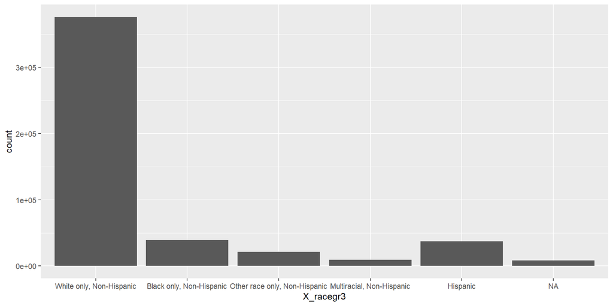

```r
ggplot(data=brfss2013, aes(x=X_racegr3)) + geom_histogram(stat = 'count')
```

Now let’s check the data `X_educag`

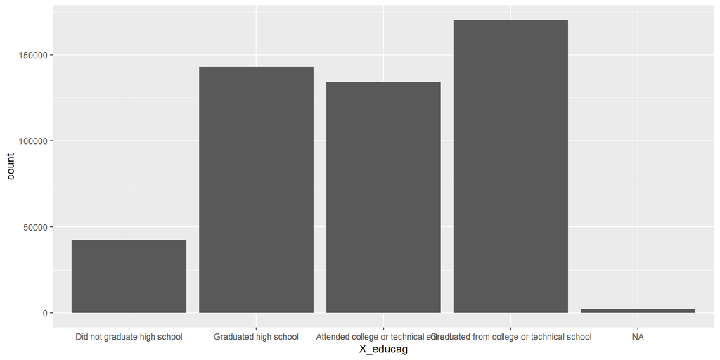

```r
ggplot(data=brfss2013, aes(x=X_educag)) + geom_histogram(stat = 'count', binwidth = 1)
```

Here we see that the number of `NA` values are very less compared to the actual respondent frequency. So we can safely ignore these.

After ignoring the `NA` values.

```r
brfss2013 %>%
  filter(!is.na(X_educag), !is.na(X_racegr3)) %>%
  group_by(X_racegr3) %>%
  summarise(count = n())
```

```
## # A tibble: 5 x 2
##   X_racegr3                      count
##   <fct>                          <int>
## 1 White only, Non-Hispanic      375023
## 2 Black only, Non-Hispanic       39104
## 3 Other race only, Non-Hispanic  21292
## 4 Multiracial, Non-Hispanic       9090
## 5 Hispanic                       36791
```

Now let’s also check out the education level data.

```r
brfss2013 %>%
  filter(!is.na(X_educag), !is.na(X_racegr3)) %>%
  group_by(X_educag) %>%
  summarise(count = n())
```

```
## # A tibble: 4 x 2
##   X_educag                                    count
##   <fct>                                       <int>
## 1 Did not graduate high school                41164
## 2 Graduated high school                      140690
## 3 Attended college or technical school       132141
## 4 Graduated from college or technical school 167305
```

We are most interested in the part of `Did not graduate high school` row. We need to find the segregation of this data along the racial demography. For this we create a new table where we store the counts based on races.

```r
tab_not_high_school <- brfss2013 %>%
  filter(!is.na(X_educag), !is.na(X_racegr3), X_educag == "Did not graduate high school") %>%
  group_by(X_racegr3) %>%
  summarise(count_not_graduate_h_school = n())
tab_not_high_school
```

```
## # A tibble: 5 x 2
##   X_racegr3                     count_not_graduate_h_school
##   <fct>                                               <int>
## 1 White only, Non-Hispanic                            22525
## 2 Black only, Non-Hispanic                             5537
## 3 Other race only, Non-Hispanic                        2074
## 4 Multiracial, Non-Hispanic                             868
## 5 Hispanic                                            10160
```

After this we get the total count of the racial demography, who responded to the education levels. We will ignore the `NA` values, which anyway very small in number here compared to the whole dataset.

```r
tot_race_edu <- brfss2013 %>%
  filter(!is.na(X_educag), !is.na(X_racegr3)) %>%
  group_by(X_racegr3) %>%
  summarise(count_total_race = n())
tot_race_edu
```

```
## # A tibble: 5 x 2
##   X_racegr3                     count_total_race
##   <fct>                                    <int>
## 1 White only, Non-Hispanic                375023
## 2 Black only, Non-Hispanic                 39104
## 3 Other race only, Non-Hispanic            21292
## 4 Multiracial, Non-Hispanic                 9090
## 5 Hispanic                                 36791
```

Now we merge the tables, `tab_not_high_school` and `tot_race_edu` so that we can compare the numbers.

```r
tab_not_high_school <- merge(tab_not_high_school,tot_race_edu, all=TRUE)

tab_not_high_school
```

```
##                       X_racegr3 count_not_graduate_h_school count_total_race
## 1      Black only, Non-Hispanic                        5537            39104
## 2                      Hispanic                       10160            36791
## 3     Multiracial, Non-Hispanic                         868             9090
## 4 Other race only, Non-Hispanic                        2074            21292
## 5      White only, Non-Hispanic                       22525           375023
```

Now we calculate the conditional probability that given the race of the respondent what is probability that he/she didn’t graduate high school. We put this in the variable `cond_prop_edu_race`

```r
tab_not_high_school <- tab_not_high_school %>%
  mutate(cond_prop_edu_race = count_not_graduate_h_school/count_total_race)

tab_not_high_school
```

```
##                       X_racegr3 count_not_graduate_h_school count_total_race
## 1      Black only, Non-Hispanic                        5537            39104
## 2                      Hispanic                       10160            36791
## 3     Multiracial, Non-Hispanic                         868             9090
## 4 Other race only, Non-Hispanic                        2074            21292
## 5      White only, Non-Hispanic                       22525           375023
##   cond_prop_edu_race
## 1         0.14159677
## 2         0.27615449
## 3         0.09548955
## 4         0.09740748
## 5         0.06006298
```

Let us visualize the results.

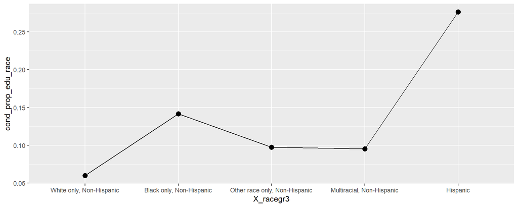

```r
ggplot(data = tab_not_high_school, aes(x=X_racegr3, y=cond_prop_edu_race)) + geom_point(size = 3) + geom_line(aes(group=1))
```

We see that conditional probability of not graduating high school varies largely across the races.The Hispanic and the Black population tend to show high probability of not graduating from high school. This data can only be generalized among the population who own telephones.

**Research quesion 2:**

For this we will look at the variable `X_rfhlth`, which signifies health in two different categories, as `Good or Better Health` and `Fair or Poor Health`. We will also compare this with the variable, `X_frtlt1`, which tells us whether fruit consumption is one or more than one per day or not and `X_veglt1` which tells us whether vegetables consumption is one or more than per day or not.

Now we will check the responses of `X_rfhlth` and check how it is distributed.

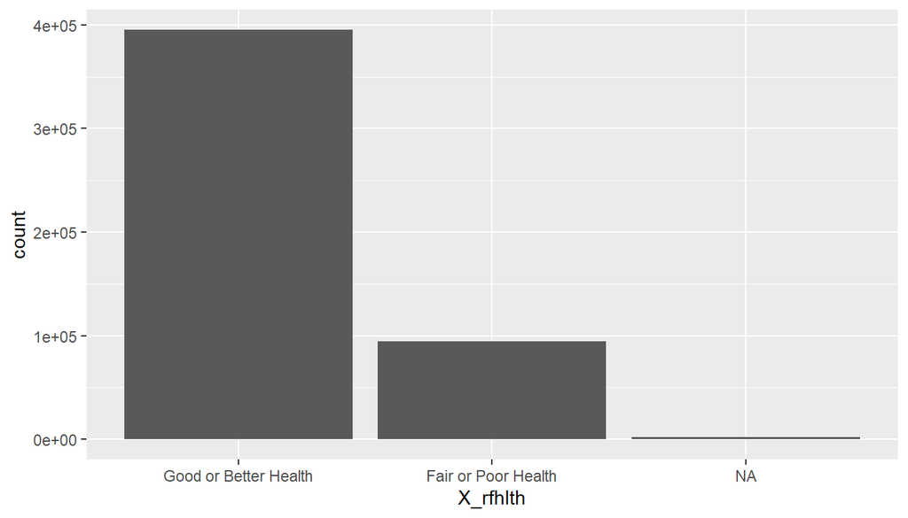

```r
ggplot(data = brfss2013, aes(x=X_rfhlth)) + geom_histogram(stat = "count")
```

We see that most of the respondents report that their health is `Good or Better Health`. Here in this research question we are exploring consumption of fruits and vegetables both. Let’s see how these variables combined are distributed. For this we will use the `group_by` and `summarise` functions.

```r
brfss2013 %>%
  filter(!is.na(X_rfhlth), !is.na(X_frtlt1), !is.na(X_veglt1)) %>%
  group_by( X_frtlt1, X_veglt1) %>%
  summarise(count = n())
```

```
## # A tibble: 4 x 3
## # Groups:   X_frtlt1 [2]
##   X_frtlt1                           X_veglt1                              count
##   <fct>                              <fct>                                 <int>
## 1 Consumed fruit one or more times ~ Consumed vegetables one or more tim~ 250091
## 2 Consumed fruit one or more times ~ Consumed vegetables less than one t~  39412
## 3 Consumed fruit less than one time~ Consumed vegetables one or more tim~ 107907
## 4 Consumed fruit less than one time~ Consumed vegetables less than one t~  61197
```

We see that a good number of people respond that they consume fruits and vegetables one or more times a day. Now we will create a new table, which will store, the counts of people who reported `Good or Better Health`, grouped by fruit and vegetable consumption scenarios.

```r
gd_hlth_frt_veg <- brfss2013 %>%
  filter(!is.na(X_rfhlth), !is.na(X_frtlt1), !is.na(X_veglt1), X_rfhlth == "Good or Better Health") %>%
  group_by( X_frtlt1, X_veglt1) %>%
  summarise(count_gd_heath = n())
gd_hlth_frt_veg
```

```
## # A tibble: 4 x 3
## # Groups:   X_frtlt1 [2]
##   X_frtlt1                       X_veglt1                         count_gd_heath
##   <fct>                          <fct>                                     <int>
## 1 Consumed fruit one or more ti~ Consumed vegetables one or more~         210389
## 2 Consumed fruit one or more ti~ Consumed vegetables less than o~          29657
## 3 Consumed fruit less than one ~ Consumed vegetables one or more~          86089
## 4 Consumed fruit less than one ~ Consumed vegetables less than o~          44377
```

For this research question what we are trying to calculate is conditional probability of `Good or Better Health` given the different scenarios of fruit and vegetable consumption. So we need the total counts of fruit and vegetable consumption irrespective of health. So for this we will create another table which will store the total counts.

```r
total_frt_veg <- brfss2013 %>%
  filter(!is.na(X_rfhlth), !is.na(X_frtlt1), !is.na(X_veglt1)) %>%
  group_by( X_frtlt1, X_veglt1) %>%
  summarise(total_count = n())
total_frt_veg
```

```
## # A tibble: 4 x 3
## # Groups:   X_frtlt1 [2]
##   X_frtlt1                        X_veglt1                           total_count
##   <fct>                           <fct>                                    <int>
## 1 Consumed fruit one or more tim~ Consumed vegetables one or more t~      250091
## 2 Consumed fruit one or more tim~ Consumed vegetables less than one~       39412
## 3 Consumed fruit less than one t~ Consumed vegetables one or more t~      107907
## 4 Consumed fruit less than one t~ Consumed vegetables less than one~       61197
```

After this we merge the two tables so that the information is there in one single table and make our subsequent calculation easier.

```r
gd_hlth_frt_veg <- merge(gd_hlth_frt_veg,total_frt_veg, all = TRUE)
gd_hlth_frt_veg
```

```
##                                    X_frtlt1
## 1 Consumed fruit less than one time per day
## 2 Consumed fruit less than one time per day
## 3  Consumed fruit one or more times per day
## 4  Consumed fruit one or more times per day
##                                         X_veglt1 count_gd_heath total_count
## 1 Consumed vegetables less than one time per day          44377       61197
## 2  Consumed vegetables one or more times per day          86089      107907
## 3 Consumed vegetables less than one time per day          29657       39412
## 4  Consumed vegetables one or more times per day         210389      250091
```

Now we will get the conditional probability of `Good or Better Health` given the different scenarios of fruit and vegetable consumption.

```r
gd_hlth_frt_veg <- gd_hlth_frt_veg %>% mutate(cond_prop = count_gd_heath/total_count)
gd_hlth_frt_veg
```

```
##                                    X_frtlt1
## 1 Consumed fruit less than one time per day
## 2 Consumed fruit less than one time per day
## 3  Consumed fruit one or more times per day
## 4  Consumed fruit one or more times per day
##                                         X_veglt1 count_gd_heath total_count
## 1 Consumed vegetables less than one time per day          44377       61197
## 2  Consumed vegetables one or more times per day          86089      107907
## 3 Consumed vegetables less than one time per day          29657       39412
## 4  Consumed vegetables one or more times per day         210389      250091
##   cond_prop
## 1 0.7251499
## 2 0.7978074
## 3 0.7524866
## 4 0.8412498
```

The data does show that there is dependence between general health and fruit-vegetable consumption trends. The data shows that if people add fruits and vegetable to their diets they tend to have `Good or Better Heatlh`. This conclusion is derived from randomly sampled data so these are mere observations. They don’t show any causality. There is more like the the question of generality among the population owning telephones.

**Research quesion 3:** At first we check how the respondents are distributed in the collected data. For this we will be using the varible `X_racegr3`.

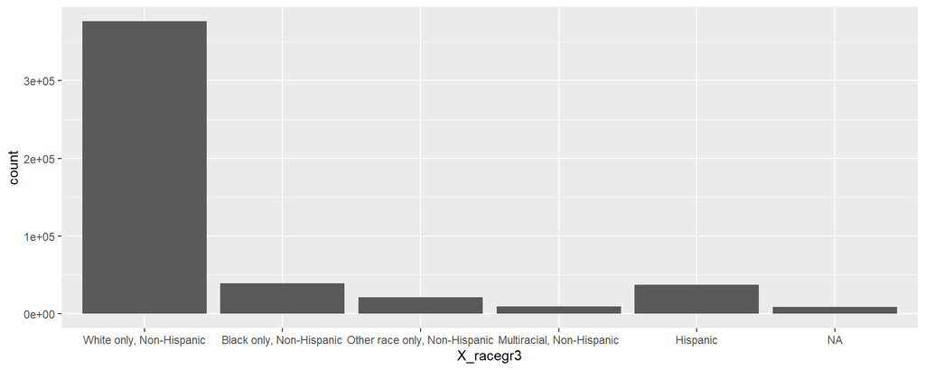

```r
ggplot(data = brfss2013, aes(x=X_racegr3)) + geom_histogram(stat = 'count')
```

We see that most of the respondents are white. So in order to find any relation between race and BMI we need to see them in probabilities.Now to check the probability of obese or overweight given that people’s race is known. At first we create a new variable in `brfss2013` table, named `is_Ovrwt_or_Obese` which will mark `YES` if the person is `Overweight` or `Obese` and `NO` otherwise.

Then we check the person’s `is_Ovrwt_or_Obese` responses, all the `YES` counts are stored in the `check_race_bmi` which gives the absolute frequency and segregates them according to race.

```r
brfss2013 <- brfss2013 %>% mutate(is_Ovrwt_or_Obese = ifelse(X_bmi5cat=='Overweight'|X_bmi5cat=='Obese',"YES","NO"))

check_race_bmi <- brfss2013 %>% filter(!is.na(dispcode), !is.na(X_racegr3),!is.na(is_Ovrwt_or_Obese), is_Ovrwt_or_Obese == "YES") %>% group_by(X_racegr3,is_Ovrwt_or_Obese) %>% summarise(count = n())
```

The above creates a table which shows, racial variability counts for BMI being `obese` or `overweight`. So let’s view the table.

```r
check_race_bmi
```

```
## # A tibble: 5 x 3
## # Groups:   X_racegr3 [5]
##   X_racegr3                     is_Ovrwt_or_Obese  count
##   <fct>                         <chr>              <int>
## 1 White only, Non-Hispanic      YES               228756
## 2 Black only, Non-Hispanic      YES                27971
## 3 Other race only, Non-Hispanic YES                11655
## 4 Multiracial, Non-Hispanic     YES                 5733
## 5 Hispanic                      YES                23139
```

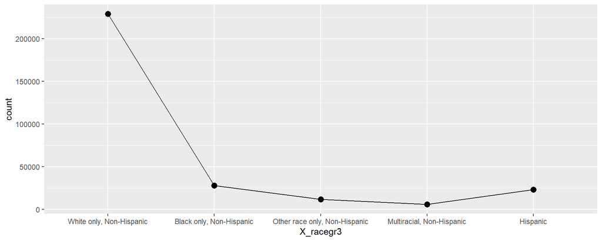

```r
ggplot(data = check_race_bmi, aes(x = X_racegr3, y = count)) + geom_point(size=3)+ geom_line(aes(group=1))
```

Now we need to gather the total counts according to the racial variabilty of those responded and store them in a new table named `total_race`.

```r
total_race <- brfss2013 %>% filter(!is.na(dispcode), !is.na(X_racegr3), !is.na(X_bmi5cat)) %>% group_by(X_racegr3) %>% summarise(total_count = n())
total_race
```

```
## # A tibble: 5 x 2
##   X_racegr3                     total_count
##   <fct>                               <int>
## 1 White only, Non-Hispanic           358378
## 2 Black only, Non-Hispanic            37015
## 3 Other race only, Non-Hispanic       20160
## 4 Multiracial, Non-Hispanic            8725
## 5 Hispanic                            33557
```

After this we will merge both the tables `check_race_bmi` and the `total_race` so that the numbers and counts can be compared.

```r
check_race_bmi <- merge(check_race_bmi, total_race, all = TRUE)
check_race_bmi
```

```
##                       X_racegr3 is_Ovrwt_or_Obese  count total_count
## 1      Black only, Non-Hispanic               YES  27971       37015
## 2                      Hispanic               YES  23139       33557
## 3     Multiracial, Non-Hispanic               YES   5733        8725
## 4 Other race only, Non-Hispanic               YES  11655       20160
## 5      White only, Non-Hispanic               YES 228756      358378
```

Now we calculate the conditional probabilty of finding a person `Obese` or `Overweight` given that his race is known.

```r
check_race_bmi <-  check_race_bmi %>% group_by(X_racegr3) %>% mutate(cond_prop = count/total_count)
check_race_bmi
```

```
## # A tibble: 5 x 5
## # Groups:   X_racegr3 [5]
##   X_racegr3                     is_Ovrwt_or_Obese  count total_count cond_prop
##   <fct>                         <chr>              <int>       <int>     <dbl>
## 1 Black only, Non-Hispanic      YES                27971       37015     0.756
## 2 Hispanic                      YES                23139       33557     0.690
## 3 Multiracial, Non-Hispanic     YES                 5733        8725     0.657
## 4 Other race only, Non-Hispanic YES                11655       20160     0.578
## 5 White only, Non-Hispanic      YES               228756      358378     0.638
```

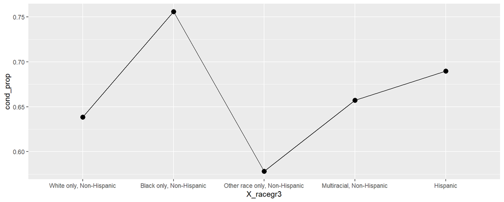

```r
ggplot(data = check_race_bmi, aes(x = X_racegr3, y = cond_prop)) + geom_point(size=3)+ geom_line(aes(group=1))
```

We do see some racial variability in the data. As the demography varies largely in the dataset, we tend to see obesity and overweight do depend on race. Although the overall data does have some bias according to the availability of telephone, the result might be generalized among the people who own telephones.